# Integration of omics and clinical data of the hormonal, metabolic, inflammatory, and oxidative response in the different macronutrients of the diet

Integration of all data sets at basal level ( log).

Edmond Geraud

16 de December, 2021

## Load the libraries

```r
> list.of.packages <- c("xlsx", "kableExtra", "dplyr", "ggplot2", "egg", "cowplot",
+     "patchwork", "gridExtra", "UsingR", "car", "lattice", "ggpubr", "ggbreak", "GGally",
+     "reshape2", "ggcorrplot", "corrplot", "rela", "ggrepel", "factoextra", "chemometrics",
+     "sparsepca", "vegan", "ca", "ade4", "pls", "OmicsPLS")
> new.packages <- list.of.packages[!(list.of.packages %in% installed.packages()[, "Package"])]  ## check for packages not installed
> if (length(new.packages)) install.packages(new.packages)  ## install packages if necessary
> res <- unlist(lapply(list.of.packages, require, character.only = T))  ## load packages needed for the session
> if (any(res == F)) {
+     list.of.packages[which(res == F)]  ## show those package if you have troubles to install.
+ }
>
> list.of.bioc.packages <- c("phyloseq", "pcaMethods", "ropls", "mixOmics")
> new.packages.bioc <- list.of.packages[!(list.of.bioc.packages %in% installed.packages()[,
+     "Package"])]
> if (length(new.packages.bioc)) BiocManager::install(new.packages.bioc)
> res.bioc <- unlist(lapply(list.of.bioc.packages, require, character.only = T))
> if (any(res.bioc == F)) {
+     list.of.packages[which(res.bioc == F)]  ## show those package if you have troubles to install.
+ }
```

# Functions for loading data (microbiome)

```r
> proces_bacteria <- function(datos,tipo){
+
+   Order <- bacteria_phylum.abs$Order
+   variables_in_bacteria <- general_data[general_data$Orden %in% Order , ]
+   Sample<-variables_in_bacteria$Paciente
+
+
+   if(tipo=="genera"){
+
+       Order <- Order
+
+       X <- datos[-1,-1]
+       X<-apply(X,2,as.numeric)
+       colnames(X) <- datos[1,2:ncol(datos)]
+       rownames(X) <- Sample
+       X.rel <- 100*X/rowSums(X)
+
+
+   } else if(tipo=="phylum"){
+
+       X <- datos[,-c(1:2)]
+       colnames(X) <- colnames(datos)[3:ncol(datos)]
+       rownames(X) <- Sample
+       X.rel<-100*X/rowSums(X)
+   }
+
+   GROUP <-variables_in_bacteria$GROUP
+   SEX <- variables_in_bacteria$SEX
+   OBESE<- variables_in_bacteria$OBESE
+
+   X<-as.data.frame(X)
+   X.rel<-as.data.frame(X.rel)
+
+   X$GROUP<-GROUP
+   X$SEX<-SEX
+   X$OBESE<-OBESE
+
+
+   X.rel$GROUP<-GROUP
+   X.rel$SEX<-SEX
+   X.rel$OBESE<-OBESE
+
+   return(list(abs=X,rel=X.rel))
+
+ }
>
>
> low.count.removal = function(
+                         data, # OTU count data frame of size n (sample) x p (OTU)
+                         percent=0.01 # cutoff chosen
+                         ){
+     keep.otu = which(colSums(data)*100/(sum(colSums(data))) > percent)
+     data.filter = data[,keep.otu]
+     return(list(data.filter = data.filter, keep.otu = keep.otu))
+ }
>
> relative.fn <-function(data){
+
+   return(100*data/colSums(data))
+
+ }
```

# Load the data

## Clinical data.

```r
> general_data <- read.xlsx(file.path(params$folder.data, params$file_general), sheetIndex = 1)
> general_data$SEX <- factor(general_data$SEX, levels = c(0, 2), labels = c("Female",
+     "Male"))
> general_data$OBESE <- factor(general_data$OBESE, levels = c(0, 1), labels = c("No Obese",
+     "Obese"))
> general_data$GROUP <- factor(general_data$GROUP, levels = c(0, 1, 2), labels = c("Female",
+     "PCOS", "Male"))
```

## IP data.

```r
> IP_file <- file.path(params$folder.data, file = params$file_IP)  ## file path of the data
> IP.tmp <- read.xlsx(IP_file, sheetIndex = 1)
> IP <- IP.tmp[, -7]  # remove the missin values column
> IP$SEX <- factor(IP$SEX, levels = c(0, 2), labels = c("Female", "Male"))
> IP$OBESE <- factor(IP$OBESE, levels = c(0, 1), labels = c("No Obese", "Obese"))
> IP$GROUP <- factor(IP$GROUP, levels = c(0, 1, 2), labels = c("Female", "PCOS", "Male"))
```

## Metabolome data

```r
> metabolome_file <- file.path(params$folder.data, file = params$file_metabolome)  ## file path of the data
> metabolome.tmp <- read.xlsx(metabolome_file, sheetIndex = 1)  # read the data
> metabolites_name <- read.xlsx(metabolome_file, sheetIndex = 2)$Metabolitos  # read the names of the metabolites
> any(is.na(metabolome.tmp))  # there is a row of missing values.
```

```
[1] TRUE
```

```r
> metabolome <- metabolome.tmp[-nrow(metabolome.tmp), ]  ## remove the missing value row
> metabolome$GROUP <- general_data$GROUP  ## add GROUP variable
> metabolome$OBESE <- general_data$OBESE  ## add OBESE variables.
```

## Microbiome data.

```r
> bacteria_phylum.abs <- as.data.frame(read.xlsx(file.path(params$folder.data, params$file_microbiota),
+     sheetIndex = 1))
> bacteria_genera.abs <- as.data.frame(t(read.xlsx(file.path(params$folder.data, params$file_microbiota),
+     sheetIndex = 3)))
> phylum.list <- proces_bacteria(bacteria_phylum.abs, tipo = "phylum")
> genera.list <- proces_bacteria(bacteria_genera.abs, tipo = "genera")
>
> phylum.abs <- phylum.list$abs
> phylum.rel <- phylum.list$rel
> genera.abs <- genera.list$abs
> genera.rel <- genera.list$rel
```

# Preprocess data according to the microbiome.

Because we have less subjects on the microbiome, and we have phylum and genera with variables with no records across all samples, we have to clean that.

Furthermore, we have to take care only the basal levels across all blocks. Also we have to clean the data on the metabolome, IP for repeated variables.

```r
> variables_in_bacteria <- general_data[general_data$Orden %in% bacteria_phylum.abs$Order,
+     ]
```

Because, we only take care of the GROUP, and OBESE variables on the analysis, we can get rid off this variables and store them apart in a new object. Furthermore, we have to have the same names for the rows, so let’s keep it in another object.

```r
> sujetos <- variables_in_bacteria$Paciente
> GROUP <- variables_in_bacteria$GROUP
> OBESE <- variables_in_bacteria$OBESE
> interaccion <- with(variables_in_bacteria, interaction(GROUP, OBESE))
```

## Clinical data.

**NOTE we are going to include also on both levels of integration body measures** We exclude ISI because it is measured after the load of glucose, the mean values, to exclude redundancy of the data, ant the postprandial levels.

```r
> Clin.tmp <- variables_in_bacteria[, -c(1, 2, 3, 4, 5)]  # get rid off orden, paciente, sex, group and obese
> auc_clin <- colnames(Clin.tmp)[grep("AUC", colnames(Clin.tmp))]
> mean_basal_clin <- colnames(Clin.tmp)[grep("mean", colnames(Clin.tmp))]
> isi <- colnames(Clin.tmp)[grep("ISI", colnames(Clin.tmp))]
> variables_clin <- colnames(Clin.tmp)
> w <- c(which(variables_clin %in% auc_clin), which(variables_clin %in% mean_basal_clin),
+     which(variables_clin %in% isi))
> Clin <- Clin.tmp[, -w]
> rownames(Clin) <- sujetos
```

## IP data

```r
> IP.tmp <- IP[IP$Paciente %in% variables_in_bacteria$Paciente, ]
> redundant_variables <- c("Orden", "Paciente", "SEX", "GROUP", "OBESE", "BMI")
> variables_ip <- colnames(IP.tmp)
> auc_ip <- variables_ip[grep("AUC", variables_ip)]
> mean_ip <- variables_ip[grep("mean", variables_ip)]
> w <- c(which(variables_ip %in% redundant_variables), which(variables_ip %in% auc_ip),
+     which(variables_ip %in% mean_ip))
> IP.basal <- IP.tmp[, -w]
> rownames(IP.basal) <- sujetos
```

## Metabolome data.

```r
> metabolome.basal.tmp <- metabolome[metabolome$Order %in% variables_in_bacteria$Orden,
+     ]
> redundant_data_meta <- c("Order", "Sample", "GROUP", "OBESE")
> variables_meta <- colnames(metabolome.basal.tmp)
> mean_meta <- variables_meta[grep("mean", variables_meta)]
> auc_meta <- variables_meta[grep("AU[CG]", variables_meta)]
> w <- c(which(variables_meta %in% redundant_data_meta), which(variables_meta %in%
+     mean_meta), which(variables_meta %in% auc_meta))
> metabolome.basal <- metabolome.basal.tmp[, -w]
> rownames(metabolome.basal) <- sujetos
```

## Microbiome data.

### Phylum.

```r
> phylum.abs.tmp <- phylum.abs
> redundant_data_ph <- c("GROUP", "SEX", "OBESE")
> phylum.tmp <- phylum.abs.tmp[, -c(ncol(phylum.abs.tmp) - 2, ncol(phylum.abs.tmp) -
+     1, ncol(phylum.abs.tmp))]
> phylum <- phylum.tmp[, colSums(phylum.tmp) > 0]
> rownames(phylum) <- sujetos
> ## removal of unidentified phyla
> phylum <- phylum[, -grep("^ud", colnames(phylum))]
```

### Genus

```r
> genera.abs.tmp <- genera.abs
> redundant_data_ph <- c("GROUP", "SEX", "OBESE")
> genus.tmp.tmp <- genera.abs.tmp[, -c(ncol(genera.abs.tmp) - 2, ncol(genera.abs.tmp) -
+     1, ncol(genera.abs.tmp))]
> genus <- genus.tmp.tmp[, colSums(genus.tmp.tmp) > 0]
> rownames(genus) <- sujetos
> ## removal of genus unidentified
>
> genus <- genus[, -grep("^ud-", colnames(genus))]
```

## Pretreatment of microbiome data.

```r
> genus.offset <- genus + 1
> phylum.offset <- phylum + 1
> sum(which(genus.offset == 0))
```

```
[1] 0
```

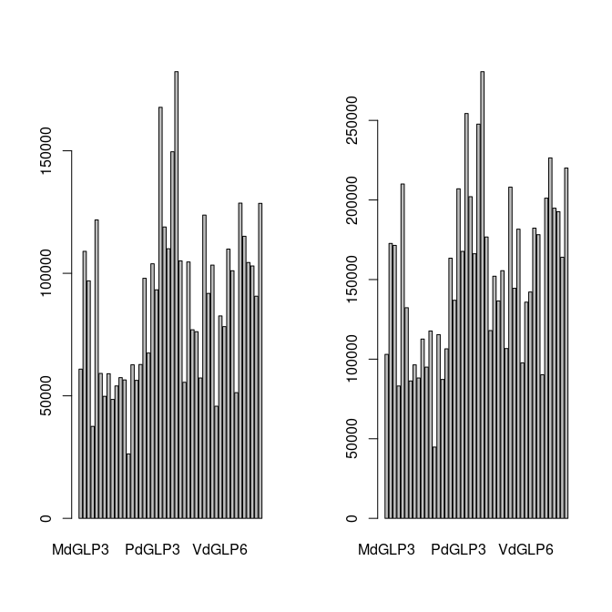

```r
> result.filter.genus <- low.count.removal(genus.offset, percent = 0.001)
> result.filter.phylum <- low.count.removal(phylum.offset, percent = 0.001)
>
> genus.filter <- result.filter.genus$data.filter
> phylum.filter <- result.filter.phylum$data.filter
>
> # length(result.filter$keep.otu)
> lib.size.genus <- apply(genus.filter, 1, sum)
> lib.size.phylum <- apply(phylum.filter, 1, sum)
> par(mfrow = c(1, 2))
> barplot(lib.size.genus)
> barplot(lib.size.phylum)
```

```r
> genus.clr <- logratio.transfo(as.matrix(genus.filter), logratio = "CLR", offset = 0)
> genus.rel <- relative.fn(genus)
```

# ENTER TRANSFORMATION

```r
> genus <- genus.clr
>
> phylum.clr <- logratio.transfo(as.matrix(phylum.filter), logratio = "CLR", offset = 0)
> phylum.rel <- relative.fn(phylum)
>
> phylum <- phylum.clr
```

# METABOLOME-MICROBIOME

## PLS2

### Genus

```r
> datos <- list(metabolome = metabolome.basal, microbiome = genus)
> pls_obj <- plsr(as.matrix(datos$metabolome) ~ as.matrix(datos$microbiome), val.type = "CV",
+     center = T, scale = T, explvar = T)
>
> rho <- diag(cor(pls_obj$scores[, 1:2], pls_obj$Yscores[, 1:2]))
```

```r
> Group <- variables_in_bacteria$GROUP
> Group2 <- variables_in_bacteria$OBESE
> X <- pls_obj$scores
> colnames(X) <- paste0("met", paste0("comp", 1:length(colnames(X))))
> Y <- pls_obj$Yscores
> colnames(Y) <- paste0("micro", paste0("comp", 1:length(colnames(Y))))
> datos <- data.frame(cbind(X, Y))
> str(datos)
```

```
'data.frame':   46 obs. of  90 variables:
 $ metcomp1   : num  3.373 -5.142 -0.811 5.375 -2.882 ...
 $ metcomp2   : num  2.977 0.375 -0.992 1.137 3.826 ...
 $ metcomp3   : num  0.393 -1.809 3.173 -4.509 1.829 ...
 $ metcomp4   : num  -0.56 -0.148 1.57 0.881 6.861 ...
 $ metcomp5   : num  0.305 -1.508 -3.78 0.516 -9.299 ...
 $ metcomp6   : num  0.271 1.012 -2.016 -4.48 -0.885 ...
 $ metcomp7   : num  1.18 2.17 -2.09 3.7 -2.33 ...
 $ metcomp8   : num  2.1947 2.6661 1.0374 -0.0212 -0.6367 ...
 $ metcomp9   : num  -1.91 -1.28 1.11 1.85 2.7 ...
 $ metcomp10  : num  3.936 -0.938 1.238 2.002 -0.843 ...
 $ metcomp11  : num  0.214 -2.475 -1.459 0.426 2.215 ...
 $ metcomp12  : num  -0.62 -0.175 1.839 1.295 -0.381 ...
 $ metcomp13  : num  -1.191 0.664 0.224 -1.706 -2.196 ...
 $ metcomp14  : num  -1.677 -0.421 -2.937 -2.647 0.913 ...
```

[output cut: 76 more lines]

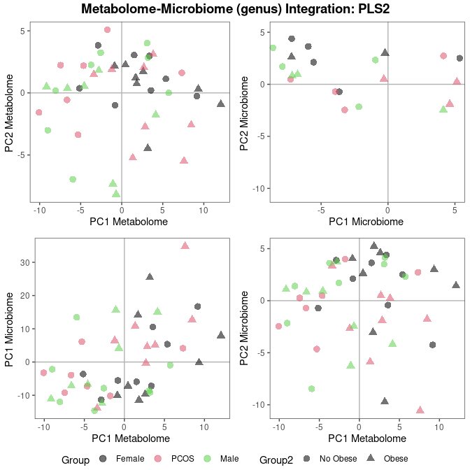

```r
> p1 <- ggplot(datos, aes(metcomp1, metcomp2)) + theme_article() + geom_hline(yintercept = 0,
+     color = "gray70") + geom_vline(xintercept = 0, color = "gray70") + geom_point(aes(color = Group,
+     shape = Group2), alpha = 0.55, size = 3) + coord_cartesian(xlim = c(min(datos[,
+     1]), max(datos[, 1]))) + scale_fill_discrete(name = "Group")
>
>
> grafico1 <- p1 + labs(x = c(paste("PC1 Metabolome ")), y = c(paste("PC2 Metabolome "))) +
+     theme(plot.title = element_text(hjust = 0.5), legend.position = "none") + scale_color_manual(values = 1:3)
>
> p2 <- ggplot(datos, aes(microcomp1, microcomp2)) + theme_article() + geom_hline(yintercept = 0,
+     color = "gray70") + geom_vline(xintercept = 0, color = "gray70") + geom_point(aes(color = Group,
+     shape = Group2), alpha = 0.55, size = 3) + coord_cartesian(xlim = c(min(datos[,
+     2]), max(datos[, 2]))) + scale_fill_discrete(name = "Group")
>
>
> grafico2 <- p2 + labs(x = c(paste("PC1 Microbiome ")), y = c(paste("PC2 Microbiome "))) +
+     theme(plot.title = element_text(hjust = 0.5), legend.position = "none") + scale_color_manual(values = 1:3)
>
> p3 <- ggplot(datos, aes(metcomp1, microcomp1)) + theme_article() + geom_hline(yintercept = 0,
+     color = "gray70") + geom_vline(xintercept = 0, color = "gray70") + geom_point(aes(color = Group,
+     shape = Group2), alpha = 0.55, size = 3) + coord_cartesian(xlim = c(min(datos[,
+     1]), max(datos[, 1]))) + scale_fill_discrete(name = "Group")
>
>
> grafico3 <- p3 + labs(x = c(paste("PC1 Metabolome ")), y = c(paste("PC1 Microbiome "))) +
+     theme(plot.title = element_text(hjust = 0.5), legend.position = "none") + scale_color_manual(values = 1:3)
>
>
> p4 <- ggplot(datos, aes(metcomp1, microcomp2)) + theme_article() + geom_hline(yintercept = 0,
+     color = "gray70") + geom_vline(xintercept = 0, color = "gray70") + geom_point(aes(color = Group,
+     shape = Group2), alpha = 0.55, size = 3) + coord_cartesian(xlim = c(min(datos[,
+     1]), max(datos[, 1]))) + scale_fill_discrete(name = "Group")
>
>
> grafico4 <- p4 + labs(x = c(paste("PC1 Metabolome")), y = c(paste("PC2 Microbiome"))) +
+     theme(plot.title = element_text(hjust = 0.5), legend.position = "none") + scale_color_manual(values = 1:3)
>
> pls2.plot <- ggarrange(grafico1, grafico2, grafico3, grafico4, common.legend = T,
+     nrow = 2, ncol = 2, legend = "bottom")
>
> annotate_figure(pls2.plot, top = text_grob("Metabolome-Microbiome (genus) Integration: PLS2",
+     color = "black", face = "bold", size = 14))
```

### Phylum

```r
> datos <- list(metabolome = metabolome.basal, microbiome = phylum)
> pls_obj <- plsr(as.matrix(datos$metabolome) ~ as.matrix(datos$microbiome), val.type = "CV",
+     center = T, scale = T, explvar = T)
>
> rho <- diag(cor(pls_obj$scores[, 1:2], pls_obj$Yscores[, 1:2]))
```

```r
> Group <- variables_in_bacteria$GROUP
> Group2 <- variables_in_bacteria$OBESE
> X <- pls_obj$scores
> colnames(X) <- paste0("met", paste0("comp", 1:length(colnames(X))))
> Y <- pls_obj$Yscores
> colnames(Y) <- paste0("micro", paste0("comp", 1:length(colnames(Y))))
> datos <- data.frame(cbind(X, Y))
> str(datos)
```

```
'data.frame':   46 obs. of  20 variables:
 $ metcomp1   : num  1.703 0.387 -0.944 -0.984 -0.536 ...
 $ metcomp2   : num  -1.614 0.175 1.247 0.294 1.849 ...
 $ metcomp3   : num  0.628 -0.9618 0.7827 0.5412 -0.0599 ...
 $ metcomp4   : num  0.6419 -1.6469 0.0579 -0.6099 0.044 ...
 $ metcomp5   : num  0.171 -0.231 0.633 -1.461 1.187 ...
 $ metcomp6   : num  -1.374 -0.324 -1.547 0.149 -1.705 ...
 $ metcomp7   : num  0.917 0.497 -0.133 -1.416 -1.643 ...
 $ metcomp8   : num  0.0171 -0.6967 0.1366 -0.9457 0.3684 ...
 $ metcomp9   : num  -0.0793 -0.3318 1.2572 -1.8483 -0.4915 ...
 $ metcomp10  : num  -1.65e-15 2.67e-17 8.08e-16 -3.44e-16 6.28e-17 ...
 $ microcomp1 : num  3.16 1.55 2.28 1.38 4.16 ...
 $ microcomp2 : num  -0.329 -0.344 -0.828 3.227 -1.589 ...
 $ microcomp3 : num  -0.162 0.3 2.481 2.203 3.755 ...
 $ microcomp4 : num  0.12 0.254 2.434 -1.541 4.785 ...
 $ microcomp5 : num  -0.981 1.776 1.705 -5.199 2.086 ...
 $ microcomp6 : num  -1.16 -3.45 -4.19 -1.08 -5.85 ...
 $ microcomp7 : num  -3.386 -0.927 -4.193 -9.46 -8.264 ...
 $ microcomp8 : num  1.365 -3.827 -2.851 -0.745 -5.55 ...
 $ microcomp9 : num  -2.14 -4.55 -1.64 -1.07 -1.84 ...
 $ microcomp10: num  2.79e-14 7.18e-13 8.14e-13 -5.39e-13 1.61e-12 ...
```

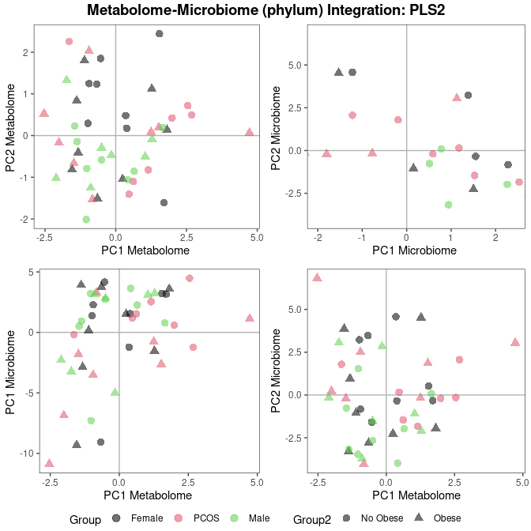

```r
> p1 <- ggplot(datos, aes(metcomp1, metcomp2)) + theme_article() + geom_hline(yintercept = 0,
+     color = "gray70") + geom_vline(xintercept = 0, color = "gray70") + geom_point(aes(color = Group,
+     shape = Group2), alpha = 0.55, size = 3) + coord_cartesian(xlim = c(min(datos[,
+     1]), max(datos[, 1]))) + scale_fill_discrete(name = "Group")
>
>
> grafico1 <- p1 + labs(x = c(paste("PC1 Metabolome ")), y = c(paste("PC2 Metabolome "))) +
+     theme(plot.title = element_text(hjust = 0.5), legend.position = "none") + scale_color_manual(values = 1:3)
>
> p2 <- ggplot(datos, aes(microcomp1, microcomp2)) + theme_article() + geom_hline(yintercept = 0,
+     color = "gray70") + geom_vline(xintercept = 0, color = "gray70") + geom_point(aes(color = Group,
+     shape = Group2), alpha = 0.55, size = 3) + coord_cartesian(xlim = c(min(datos[,
+     2]), max(datos[, 2]))) + scale_fill_discrete(name = "Group")
>
>
> grafico2 <- p2 + labs(x = c(paste("PC1 Microbiome ")), y = c(paste("PC2 Microbiome "))) +
+     theme(plot.title = element_text(hjust = 0.5), legend.position = "none") + scale_color_manual(values = 1:3)
>
> p3 <- ggplot(datos, aes(metcomp1, microcomp1)) + theme_article() + geom_hline(yintercept = 0,
+     color = "gray70") + geom_vline(xintercept = 0, color = "gray70") + geom_point(aes(color = Group,
+     shape = Group2), alpha = 0.55, size = 3) + coord_cartesian(xlim = c(min(datos[,
+     1]), max(datos[, 1]))) + scale_fill_discrete(name = "Group")
>
>
> grafico3 <- p3 + labs(x = c(paste("PC1 Metabolome ")), y = c(paste("PC1 Microbiome "))) +
+     theme(plot.title = element_text(hjust = 0.5), legend.position = "none") + scale_color_manual(values = 1:3)
>
>
> p4 <- ggplot(datos, aes(metcomp1, microcomp2)) + theme_article() + geom_hline(yintercept = 0,
+     color = "gray70") + geom_vline(xintercept = 0, color = "gray70") + geom_point(aes(color = Group,
+     shape = Group2), alpha = 0.55, size = 3) + coord_cartesian(xlim = c(min(datos[,
+     1]), max(datos[, 1]))) + scale_fill_discrete(name = "Group")
>
>
> grafico4 <- p4 + labs(x = c(paste("PC1 Metabolome")), y = c(paste("PC2 Microbiome"))) +
+     theme(plot.title = element_text(hjust = 0.5), legend.position = "none") + scale_color_manual(values = 1:3)
>
> pls2.plot <- ggarrange(grafico1, grafico2, grafico3, grafico4, common.legend = T,
+     nrow = 2, ncol = 2, legend = "bottom")
>
> annotate_figure(pls2.plot, top = text_grob("Metabolome-Microbiome (phylum) Integration: PLS2",
+     color = "black", face = "bold", size = 14))
```

## O2PLS

### Genus

```r
> datos <- list(metabolome = metabolome.basal, microbiome = genus)
> X <- scale(datos$metabolome)
> Y <- scale(datos$microbiome)
> n <- 1
> while (n < 2) {
+     res_cv <- crossval_o2m_adjR2(X, Y, 1:4, 0:4, 0:4, nr_folds = 3)
+     res_cv_min_mse <- res_cv[which.min(res_cv[, 1]), ]
+     n <- as.numeric(res_cv_min_mse[2])
+ }
>
>
> nx <- as.numeric(res_cv_min_mse[3])
> ny <- as.numeric(res_cv_min_mse[4])
>
> res <- o2m2(X = X, Y = Y, n = n, nx = nx, ny = ny)
```

```r
> Group <- variables_in_bacteria$GROUP
> Group2 <- variables_in_bacteria$OBESE
> Tt <- data.frame(res$Tt)
> colnames(Tt) <- paste0("jointX_", paste0("comp", 1:length(colnames(Tt))))
> U <- data.frame(res$U)
> colnames(U) <- paste0("jointY_", paste0("comp", 1:length(colnames(U))))
> T_Y <- data.frame(res$T_Yosc)
> colnames(T_Y) <- paste0("OrthX_", paste0("comp", 1:length(colnames(T_Y))))
> U_X <- data.frame(res$U_Xosc)
> colnames(U_X) <- paste0("OrthY_", paste0("comp", 1:length(colnames(U_X))))
>
>
> ## Firstly let's compute the joint variantes.
>
> p1 <- ggplot(Tt, aes(jointX_comp1, jointX_comp2)) + theme_article() + geom_hline(yintercept = 0,
+     color = "gray70") + geom_vline(xintercept = 0, color = "gray70") + geom_point(aes(color = Group,
+     shape = Group2), alpha = 0.55, size = 3) + coord_cartesian(xlim = c(min(Tt[,
+     1]), max(Tt[, 1]))) + scale_fill_discrete(name = "Group")
>
>
> grafico1 <- p1 + labs(x = c(paste("Joint comp 1", round(100 * res$R2Xcorr, 2), "%")),
+     y = "Joint comp 2") + ggtitle(paste("Metabolome", sep = " ")) + theme(plot.title = element_text(hjust = 0.5,
+     size = 10), legend.position = "none", axis.title = element_text(size = 9)) +
+     scale_color_manual(values = 1:3)
>
> p2 <- ggplot(U, aes(jointY_comp1, jointY_comp2)) + theme_article() + geom_hline(yintercept = 0,
+     color = "gray70") + geom_vline(xintercept = 0, color = "gray70") + geom_point(aes(color = Group,
+     shape = Group2), alpha = 0.55, size = 3) + coord_cartesian(xlim = c(min(U[, 1]),
+     max(U[, 1]))) + scale_fill_discrete(name = "Group")
>
>
> grafico2 <- p2 + labs(x = c(paste("Joint comp 1", round(100 * res$R2Ycorr, 2), "%")),
+     y = "Joint comp 2") + ggtitle(paste("Microbiome", sep = " ")) + theme(plot.title = element_text(hjust = 0.5,
+     size = 10), legend.position = "none", axis.title = element_text(size = 9)) +
+     scale_color_manual(values = 1:3)
>
> ## Now let-s compute joint between
>
> datos <- data.frame(cbind(Tt, U))
> p3 <- ggplot(datos, aes(jointX_comp1, jointY_comp2)) + theme_article() + geom_hline(yintercept = 0,
+     color = "gray70") + geom_vline(xintercept = 0, color = "gray70") + geom_point(aes(color = Group,
+     shape = Group2), alpha = 0.55, size = 3) + coord_cartesian(xlim = c(min(datos[,
+     1]), max(datos[, 1]))) + scale_fill_discrete(name = "Group")
>
>
> grafico3 <- p3 + labs(x = c(paste("Joint comp 1 Metabolome", round(100 * res$R2Xcorr,
+     2), "%")), y = c(paste("Joint comp 2 Micrbiome", round(100 * res$R2Ycorr, 2),
+     "%"))) + ggtitle(paste("Microbiome-Metabolome", sep = " ")) + theme(plot.title = element_text(hjust = 0.5,
+     size = 10), legend.position = "none", axis.title = element_text(size = 9)) +
+     scale_color_manual(values = 1:3)
>
>
> ## let's compute thre joint and orthogonal between
>
>
> datos <- data.frame(cbind(Tt, T_Y))
> p4 <- ggplot(datos, aes(jointX_comp1, OrthX_comp1)) + theme_article() + geom_hline(yintercept = 0,
+     color = "gray70") + geom_vline(xintercept = 0, color = "gray70") + geom_point(aes(color = Group,
+     shape = Group2), alpha = 0.55, size = 3) + coord_cartesian(xlim = c(min(datos[,
+     1]), max(datos[, 1]))) + scale_fill_discrete(name = "Group")
>
>
> grafico4 <- p4 + labs(x = c(paste("Joint comp 1", round(100 * res$R2Xcorr, 2), "%")),
+     y = c(paste("Orthogonal comp 1", round(100 * res$R2X_YO, 2), "%"))) + ggtitle(paste("Metabolome",
+     sep = " ")) + theme(plot.title = element_text(hjust = 0.5, size = 10), legend.position = "none",
+     axis.title = element_text(size = 9)) + scale_color_manual(values = 1:3)
>
> datos <- data.frame(cbind(U, U_X))
> p5 <- ggplot(datos, aes(jointY_comp1, OrthY_comp1)) + theme_article() + geom_hline(yintercept = 0,
+     color = "gray70") + geom_vline(xintercept = 0, color = "gray70") + geom_point(aes(color = Group,
+     shape = Group2), alpha = 0.55, size = 3) + coord_cartesian(xlim = c(min(datos[,
+     1]), max(datos[, 1]))) + scale_fill_discrete(name = "Group")
>
>
> grafico5 <- p5 + labs(x = c(paste("Joint comp 1", round(100 * res$R2Ycorr, 2), "%")),
+     y = c(paste("Orthogonal comp 1", round(100 * res$R2Y_XO, 2), "%"))) + ggtitle(paste("Microbiome-Metabolome",
+     sep = " ")) + theme(plot.title = element_text(hjust = 0.5, size = 10), legend.position = "none",
+     axis.title = element_text(size = 9)) + scale_color_manual(values = 1:3)
>
> ## Now between orthogonal.
>
> datos <- data.frame(cbind(T_Y, U_X))
> p6 <- ggplot(datos, aes(OrthX_comp1, OrthY_comp1)) + theme_article() + geom_hline(yintercept = 0,
+     color = "gray70") + geom_vline(xintercept = 0, color = "gray70") + geom_point(aes(color = Group,
+     shape = Group2), alpha = 0.55, size = 3) + coord_cartesian(xlim = c(min(datos[,
+     1]), max(datos[, 1]))) + scale_fill_discrete(name = "Group")
>
>
> grafico6 <- p6 + labs(x = c(paste("Orthogonal Metabolome comp 1", round(100 * res$R2X_YO,
+     2), "%")), y = c(paste("Orthogonal Microbiome comp 1", round(100 * res$R2Y_XO,
+     2), "%"))) + ggtitle(paste("Microbiome-Metabolome", sep = " ")) + theme(plot.title = element_text(hjust = 0.5,
+     size = 10), legend.position = "none", axis.title = element_text(size = 9)) +
+     scale_color_manual(values = 1:3)
```

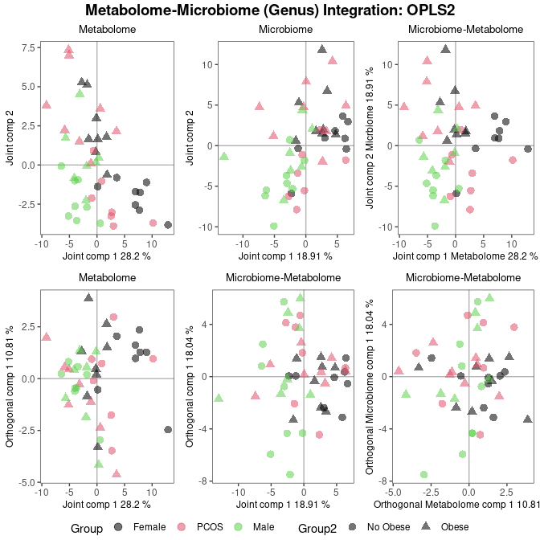

```r
> o2pl2.plot <- ggarrange(grafico1, grafico2, grafico3, grafico4, grafico5, grafico6,
+     common.legend = T, legend = "bottom")
>
> annotate_figure(o2pl2.plot, top = text_grob("Metabolome-Microbiome (Genus) Integration: OPLS2",
+     color = "black", face = "bold", size = 14))
```

### phylum

```r
> datos <- list(metabolome = metabolome.basal, microbiome = phylum)
> X <- scale(datos$metabolome)
> Y <- scale(datos$microbiome)
> n <- 1
> while (n < 2) {
+     res_cv <- crossval_o2m_adjR2(X, Y, 1:4, 0:4, 0:4, nr_folds = 3)
+     res_cv_min_mse <- res_cv[which.min(res_cv[, 1]), ]
+     n <- as.numeric(res_cv_min_mse[2])
+ }
>
>
> nx <- as.numeric(res_cv_min_mse[3])
> ny <- as.numeric(res_cv_min_mse[4])
>
> res <- o2m2(X = X, Y = Y, n = n, nx = nx, ny = ny)
```

```r
> Group <- variables_in_bacteria$GROUP
> Group2 <- variables_in_bacteria$OBESE
> Tt <- data.frame(res$Tt)
> colnames(Tt) <- paste0("jointX_", paste0("comp", 1:length(colnames(Tt))))
> U <- data.frame(res$U)
> colnames(U) <- paste0("jointY_", paste0("comp", 1:length(colnames(U))))
> T_Y <- data.frame(res$T_Yosc)
> colnames(T_Y) <- paste0("OrthX_", paste0("comp", 1:length(colnames(T_Y))))
> U_X <- data.frame(res$U_Xosc)
> colnames(U_X) <- paste0("OrthY_", paste0("comp", 1:length(colnames(U_X))))
>
>
> ## Firstly let's compute the joint variantes.
>
> p1 <- ggplot(Tt, aes(jointX_comp1, jointX_comp2)) + theme_article() + geom_hline(yintercept = 0,
+     color = "gray70") + geom_vline(xintercept = 0, color = "gray70") + geom_point(aes(color = Group,
+     shape = Group2), alpha = 0.55, size = 3) + coord_cartesian(xlim = c(min(Tt[,
+     1]), max(Tt[, 1]))) + scale_fill_discrete(name = "Group")
>
>
> grafico1 <- p1 + labs(x = c(paste("Joint comp 1", round(100 * res$R2Xcorr, 2), "%")),
+     y = "Joint comp 2") + ggtitle(paste("Metabolome", sep = " ")) + theme(plot.title = element_text(hjust = 0.5,
+     size = 10), legend.position = "none", axis.title = element_text(size = 9)) +
+     scale_color_manual(values = 1:3)
>
> p2 <- ggplot(U, aes(jointY_comp1, jointY_comp2)) + theme_article() + geom_hline(yintercept = 0,
+     color = "gray70") + geom_vline(xintercept = 0, color = "gray70") + geom_point(aes(color = Group,
+     shape = Group2), alpha = 0.55, size = 3) + coord_cartesian(xlim = c(min(U[, 1]),
+     max(U[, 1]))) + scale_fill_discrete(name = "Group")
>
>
> grafico2 <- p2 + labs(x = c(paste("Joint comp 1", round(100 * res$R2Ycorr, 2), "%")),
+     y = "Joint comp 2") + ggtitle(paste("Microbiome", sep = " ")) + theme(plot.title = element_text(hjust = 0.5,
+     size = 10), legend.position = "none", axis.title = element_text(size = 9)) +
+     scale_color_manual(values = 1:3)
>
> ## Now let-s compute joint between
>
> datos <- data.frame(cbind(Tt, U))
> p3 <- ggplot(datos, aes(jointX_comp1, jointY_comp2)) + theme_article() + geom_hline(yintercept = 0,
+     color = "gray70") + geom_vline(xintercept = 0, color = "gray70") + geom_point(aes(color = Group,
+     shape = Group2), alpha = 0.55, size = 3) + coord_cartesian(xlim = c(min(datos[,
+     1]), max(datos[, 1]))) + scale_fill_discrete(name = "Group")
>
>
> grafico3 <- p3 + labs(x = c(paste("Joint comp 1 Metabolome", round(100 * res$R2Xcorr,
+     2), "%")), y = c(paste("Joint comp 2 Micrbiome", round(100 * res$R2Ycorr, 2),
+     "%"))) + ggtitle(paste("Microbiome-Metabolome", sep = " ")) + theme(plot.title = element_text(hjust = 0.5,
+     size = 10), legend.position = "none", axis.title = element_text(size = 9)) +
+     scale_color_manual(values = 1:3)
>
>
> ## let's compute thre joint and orthogonal between
>
>
> datos <- data.frame(cbind(Tt, T_Y))
> p4 <- ggplot(datos, aes(jointX_comp1, OrthX_comp1)) + theme_article() + geom_hline(yintercept = 0,
+     color = "gray70") + geom_vline(xintercept = 0, color = "gray70") + geom_point(aes(color = Group,
+     shape = Group2), alpha = 0.55, size = 3) + coord_cartesian(xlim = c(min(datos[,
+     1]), max(datos[, 1]))) + scale_fill_discrete(name = "Group")
>
>
> grafico4 <- p4 + labs(x = c(paste("Joint comp 1", round(100 * res$R2Xcorr, 2), "%")),
+     y = c(paste("Orthogonal comp 1", round(100 * res$R2X_YO, 2), "%"))) + ggtitle(paste("Metabolome",
+     sep = " ")) + theme(plot.title = element_text(hjust = 0.5, size = 10), legend.position = "none",
+     axis.title = element_text(size = 9)) + scale_color_manual(values = 1:3)
>
> datos <- data.frame(cbind(U, U_X))
> p5 <- ggplot(datos, aes(jointY_comp1, OrthY_comp1)) + theme_article() + geom_hline(yintercept = 0,
+     color = "gray70") + geom_vline(xintercept = 0, color = "gray70") + geom_point(aes(color = Group,
+     shape = Group2), alpha = 0.55, size = 3) + coord_cartesian(xlim = c(min(datos[,
+     1]), max(datos[, 1]))) + scale_fill_discrete(name = "Group")
>
>
> grafico5 <- p5 + labs(x = c(paste("Joint comp 1", round(100 * res$R2Ycorr, 2), "%")),
+     y = c(paste("Orthogonal comp 1", round(100 * res$R2Y_XO, 2), "%"))) + ggtitle(paste("Microbiome-Metabolome",
+     sep = " ")) + theme(plot.title = element_text(hjust = 0.5, size = 10), legend.position = "none",
+     axis.title = element_text(size = 9)) + scale_color_manual(values = 1:3)
>
> ## Now between orthogonal.
>
> datos <- data.frame(cbind(T_Y, U_X))
> p6 <- ggplot(datos, aes(OrthX_comp1, OrthY_comp1)) + theme_article() + geom_hline(yintercept = 0,
+     color = "gray70") + geom_vline(xintercept = 0, color = "gray70") + geom_point(aes(color = Group,
+     shape = Group2), alpha = 0.55, size = 3) + coord_cartesian(xlim = c(min(datos[,
+     1]), max(datos[, 1]))) + scale_fill_discrete(name = "Group")
>
>
> grafico6 <- p6 + labs(x = c(paste("Orthogonal Metabolome comp 1", round(100 * res$R2X_YO,
+     2), "%")), y = c(paste("Orthogonal Microbiome comp 1", round(100 * res$R2Y_XO,
+     2), "%"))) + ggtitle(paste("Microbiome-Metabolome", sep = " ")) + theme(plot.title = element_text(hjust = 0.5,
+     size = 10), legend.position = "none", axis.title = element_text(size = 9)) +
+     scale_color_manual(values = 1:3)
```

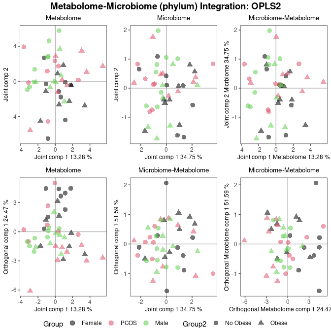

```r
> o2pl2.plot <- ggarrange(grafico1, grafico2, grafico3, grafico4, grafico5, grafico6,
+     common.legend = T, legend = "bottom")
>
> annotate_figure(o2pl2.plot, top = text_grob("Metabolome-Microbiome (phylum) Integration: OPLS2",
+     color = "black", face = "bold", size = 14))
```

## DIABLO

### Genus

#### interaccion

```r
> datos <- list(metabolome = metabolome.basal, microbiome = genus)
> res1.pls.met_micro <- mixOmics::pls(datos$metabolome, datos$microbiome, ncomp = 1)
> (rho <- cor(res1.pls.met_micro$variates$X, res1.pls.met_micro$variates$Y))
```

```
         comp1
comp1 0.561821
```

```r
> design = matrix(rho, ncol = length(datos), nrow = length(datos), dimnames = list(names(datos),
+     names(datos)))
> diag(design) = 0
> design
```

```
           metabolome microbiome
metabolome   0.000000   0.561821
microbiome   0.561821   0.000000
```

We are going to keep all variables since we do not have the power.

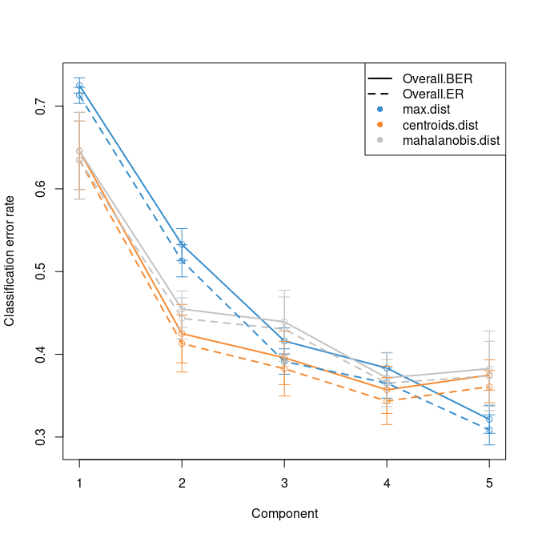

```r
> datos <- list(metabolome = metabolome.basal, microbiome = genus)
> diablo.integro.interaccion <- block.splsda(datos, Y = interaccion, ncomp = 5, design = design)
>
> set.seed(123)  # For reproducibility, remove for your analyses
> perf.diablo.integro.interaccion = perf(diablo.integro.interaccion, validation = "Mfold",
+     folds = 10, nrepeat = 5)
>
> # perf.diablo.tcga$error.rate # Lists the different types of error rates
>
> # Plot of the error rates based on weighted vote
> plot(perf.diablo.integro.interaccion)
```

```r
> (ncomp.interaccion <- perf.diablo.integro.interaccion$choice.ncomp$WeightedVote["Overall.BER",
+     "centroids.dist"])
```

```
[1] 4
```

```r
> sgccda.res_met_gen.interaccion = block.splsda(X = datos, Y = interaccion, ncomp = ncomp.interaccion,
+     design = design)
```

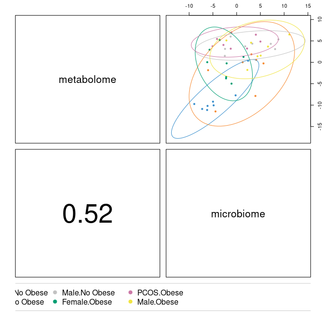

```r
> plotDiablo(sgccda.res_met_gen.interaccion, ncomp = 1)
```

```r
> # plotDiablo(sgccda.res_met_gen.interaccion, ncomp = 2)
> # plotDiablo(sgccda.res_met_gen.interaccion, ncomp = 3)
```

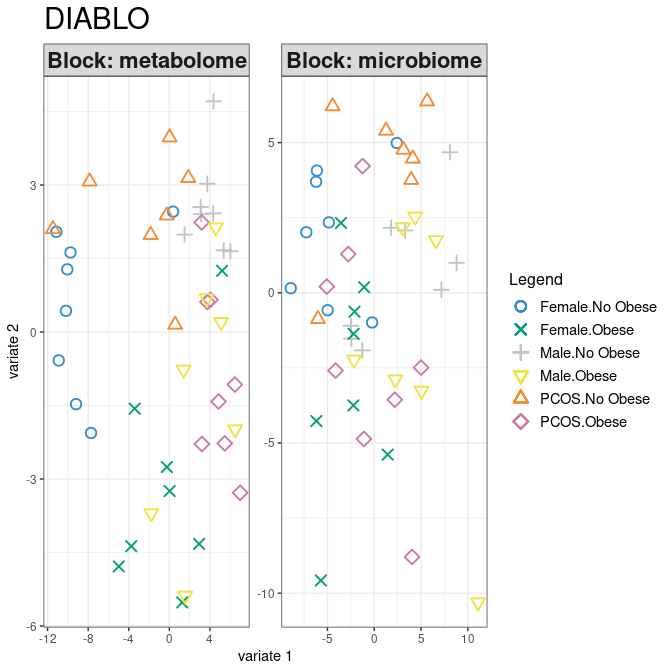

```r
> plotIndiv(sgccda.res_met_gen.interaccion, ind.names = FALSE, legend = TRUE, title = "DIABLO")
```

SCORE PLOT

```r
> Group <- variables_in_bacteria$GROUP
> Group2 <- variables_in_bacteria$OBESE
> X <- sgccda.res_met_gen.interaccion$variates$metabolome
> colnames(X) <- paste0("met", colnames(X))
> Y <- sgccda.res_met_gen.interaccion$variates$microbiome
> colnames(Y) <- paste0("micro", colnames(Y))
> datos <- data.frame(cbind(X, Y))
> str(datos)
```

```
'data.frame':   46 obs. of  8 variables:
 $ metcomp1  : num  -9.19 0.37 -7.72 -10.9 -10.19 ...
 $ metcomp2  : num  -1.471 2.457 -2.061 -0.58 0.432 ...
 $ metcomp3  : num  -0.3297 -1.9199 -2.4876 -1.4493 -0.0525 ...
 $ metcomp4  : num  3.57 -1.84 5.74 1.22 2.05 ...
 $ microcomp1: num  -4.978 2.409 -0.221 -7.258 -6.127 ...
 $ microcomp2: num  -0.58 4.988 -0.988 2.015 4.068 ...
 $ microcomp3: num  -0.453 -3.049 -1.693 -0.7 -1.427 ...
 $ microcomp4: num  0.69 1.31 6.96 1.49 10.71 ...
```

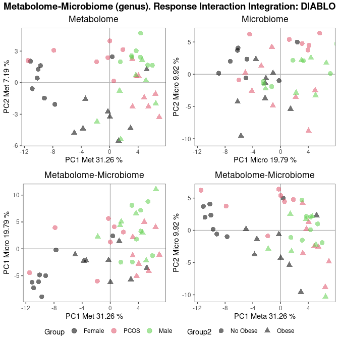

```r
> p1 <- ggplot(datos, aes(metcomp1, metcomp2)) + theme_article() + geom_hline(yintercept = 0,
+     color = "gray70") + geom_vline(xintercept = 0, color = "gray70") + geom_point(aes(color = Group,
+     shape = Group2), alpha = 0.55, size = 3) + coord_cartesian(xlim = c(min(datos[,
+     1]), max(datos[, 1]))) + scale_fill_discrete(name = "Group")
>
>
> grafico1 <- p1 + labs(x = c(paste("PC1 Met", round(100 * sgccda.res_met_gen.interaccion$prop_expl_var$metabolome[1],
+     2), "%")), y = c(paste("PC2 Met", round(100 * sgccda.res_met_gen.interaccion$prop_expl_var$metabolome[2],
+     2), "%"))) + ggtitle(paste("Metabolome", sep = " ")) + theme(plot.title = element_text(hjust = 0.5),
+     legend.position = "none") + scale_color_manual(values = 1:3)
>
> p2 <- ggplot(datos, aes(microcomp1, microcomp2)) + theme_article() + geom_hline(yintercept = 0,
+     color = "gray70") + geom_vline(xintercept = 0, color = "gray70") + geom_point(aes(color = Group,
+     shape = Group2), alpha = 0.55, size = 3) + coord_cartesian(xlim = c(min(datos[,
+     1]), max(datos[, 1]))) + scale_fill_discrete(name = "Group")
>
>
> grafico2 <- p2 + labs(x = c(paste("PC1 Micro", round(100 * sgccda.res_met_gen.interaccion$prop_expl_var$microbiome[1],
+     2), "%")), y = c(paste("PC2 Micro", round(100 * sgccda.res_met_gen.interaccion$prop_expl_var$microbiome[2],
+     2), "%"))) + ggtitle(paste("Microbiome", sep = " ")) + theme(plot.title = element_text(hjust = 0.5),
+     legend.position = "none") + scale_color_manual(values = 1:3)
>
> p3 <- ggplot(datos, aes(metcomp1, microcomp1)) + theme_article() + geom_hline(yintercept = 0,
+     color = "gray70") + geom_vline(xintercept = 0, color = "gray70") + geom_point(aes(color = Group,
+     shape = Group2), alpha = 0.55, size = 3) + coord_cartesian(xlim = c(min(datos[,
+     1]), max(datos[, 1]))) + scale_fill_discrete(name = "Group")
>
>
> grafico3 <- p3 + labs(x = c(paste("PC1 Met", round(100 * sgccda.res_met_gen.interaccion$prop_expl_var$metabolome[1],
+     2), "%")), y = c(paste("PC1 Micro", round(100 * sgccda.res_met_gen.interaccion$prop_expl_var$microbiome[1],
+     2), "%"))) + ggtitle(paste("Metabolome-Microbiome", sep = " ")) + theme(plot.title = element_text(hjust = 0.5),
+     legend.position = "none") + scale_color_manual(values = 1:3)
>
>
> p4 <- ggplot(datos, aes(metcomp1, microcomp2)) + theme_article() + geom_hline(yintercept = 0,
+     color = "gray70") + geom_vline(xintercept = 0, color = "gray70") + geom_point(aes(color = Group,
+     shape = Group2), alpha = 0.55, size = 3) + coord_cartesian(xlim = c(min(datos[,
+     1]), max(datos[, 1]))) + scale_fill_discrete(name = "Group")
>
>
> grafico4 <- p4 + labs(x = c(paste("PC1 Meta", round(100 * sgccda.res_met_gen.interaccion$prop_expl_var$metabolome[1],
+     2), "%")), y = c(paste("PC2 Micro", round(100 * sgccda.res_met_gen.interaccion$prop_expl_var$microbiome[2],
+     2), "%"))) + ggtitle(paste("Metabolome-Microbiome", sep = " ")) + theme(plot.title = element_text(hjust = 0.5),
+     legend.position = "none") + scale_color_manual(values = 1:3)
>
> p <- ggarrange(grafico1, grafico2, grafico3, grafico4, common.legend = T, nrow = 2,
+     ncol = 2, legend = "bottom")
> annotate_figure(p, top = text_grob("Metabolome-Microbiome (genus). Response Interaction Integration: DIABLO",
+     color = "black", face = "bold", size = 14))
```

### Phylum

#### GROUP

```r
> datos <- list(metabolome = metabolome.basal, microbiome = phylum)
> res1.pls.met_micro <- mixOmics::pls(datos$metabolome, datos$microbiome, ncomp = 1)
> (rho <- cor(res1.pls.met_micro$variates$X, res1.pls.met_micro$variates$Y))
```

```
          comp1
comp1 0.4973222
```

Thus, the design should be

```r
> design = matrix(rho, ncol = length(datos), nrow = length(datos), dimnames = list(names(datos),
+     names(datos)))
> diag(design) = 0
> design
```

```
           metabolome microbiome
metabolome  0.0000000  0.4973222
microbiome  0.4973222  0.0000000
```

We are going to keep all variables since we do not have the power.

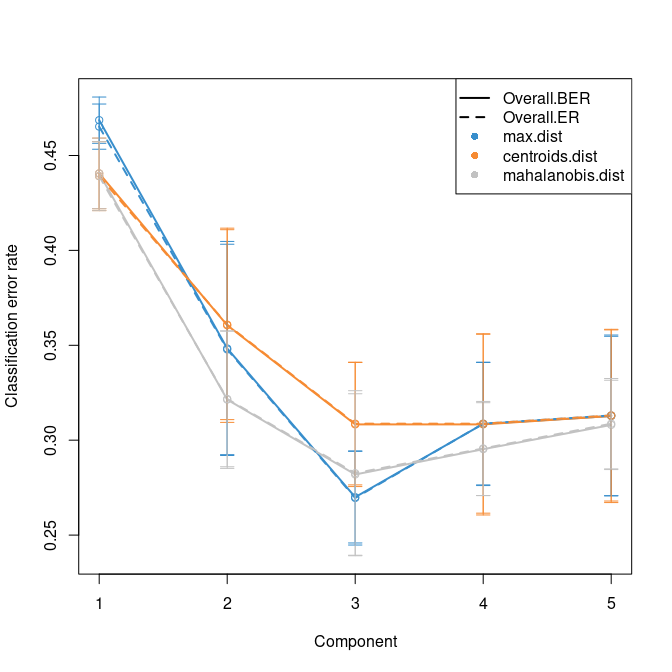

```r
> diablo.integro <- block.splsda(datos, Y = GROUP, ncomp = 5, design = design)
>
> set.seed(123)  # For reproducibility, remove for your analyses
> perf.diablo.integro = perf(diablo.integro, validation = "Mfold", folds = 10, nrepeat = 5)
>
> # perf.diablo.tcga$error.rate # Lists the different types of error rates
>
> # Plot of the error rates based on weighted vote
> plot(perf.diablo.integro)
```

```r
> (ncomp <- perf.diablo.integro$choice.ncomp$WeightedVote["Overall.BER", "centroids.dist"])
```

```
[1] 3
```

```r
> sgccda.res_met_gen = block.splsda(X = datos, Y = GROUP, ncomp = ncomp, design = design)
```

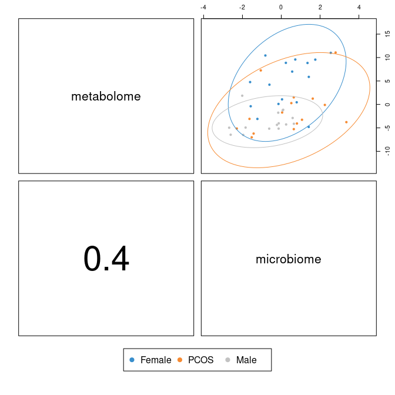

```r
> plotDiablo(sgccda.res_met_gen, ncomp = 1)
```

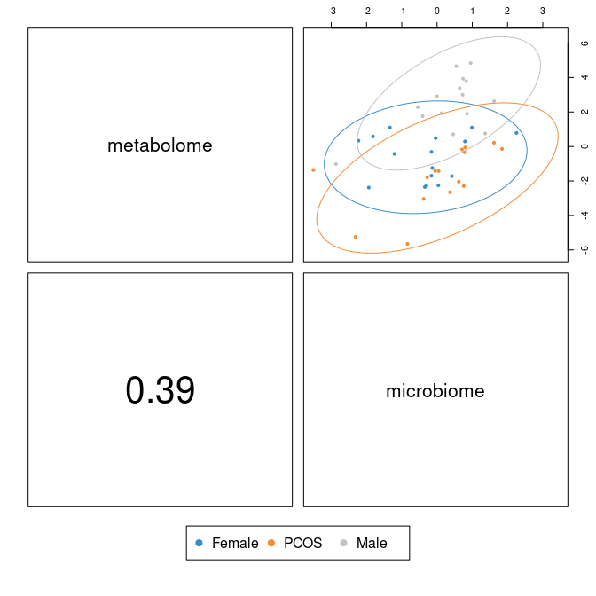

```r
> plotDiablo(sgccda.res_met_gen, ncomp = 2)
```

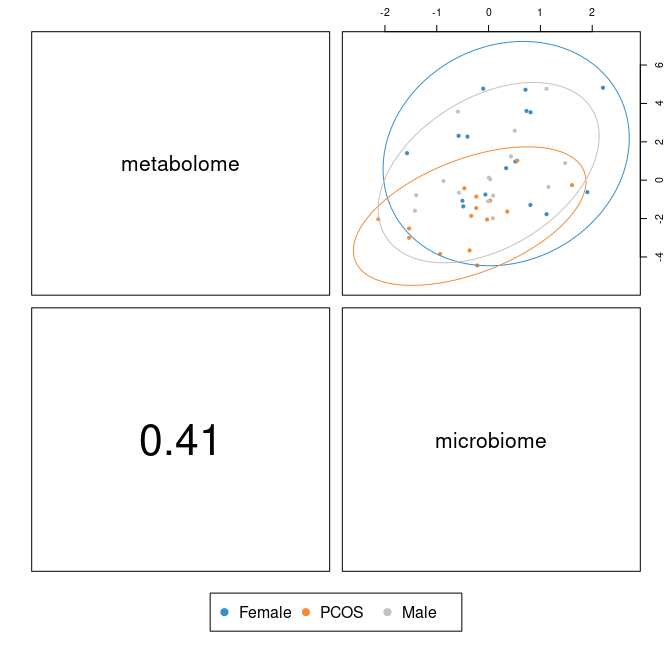

```r
> plotDiablo(sgccda.res_met_gen, ncomp = 3)
```

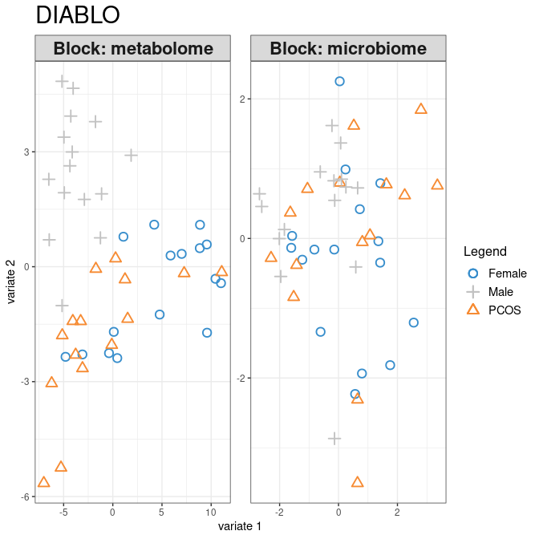

```r
> plotIndiv(sgccda.res_met_gen, ind.names = FALSE, legend = TRUE, title = "DIABLO")
```

SCORE PLOT

```r
> Group <- variables_in_bacteria$GROUP
> Group2 <- variables_in_bacteria$OBESE
> X <- sgccda.res_met_gen$variates$metabolome
> colnames(X) <- paste0("met", colnames(X))
> Y <- sgccda.res_met_gen$variates$microbiome
> colnames(Y) <- paste0("micro", colnames(Y))
> datos <- data.frame(cbind(X, Y))
> str(datos)
```

```
'data.frame':   46 obs. of  6 variables:
 $ metcomp1  : num  8.87 0.1 7 10.44 9.56 ...
 $ metcomp2  : num  1.094 -1.7 0.335 -0.315 0.58 ...
 $ metcomp3  : num  1.408 -1.072 0.968 0.628 -0.623 ...
 $ microcomp1: num  0.237 -0.144 0.564 -0.818 1.754 ...
 $ microcomp2: num  0.989 -0.159 -2.229 -0.159 -1.816 ...
 $ microcomp3: num  -1.574 -0.504 0.517 0.338 1.907 ...
```

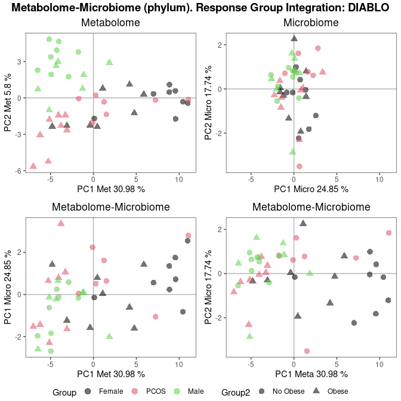

```r
> p1 <- ggplot(datos, aes(metcomp1, metcomp2)) + theme_article() + geom_hline(yintercept = 0,
+     color = "gray70") + geom_vline(xintercept = 0, color = "gray70") + geom_point(aes(color = Group,
+     shape = Group2), alpha = 0.55, size = 3) + coord_cartesian(xlim = c(min(datos[,
+     1]), max(datos[, 1]))) + scale_fill_discrete(name = "Group")
>
>
> grafico1 <- p1 + labs(x = c(paste("PC1 Met", round(100 * sgccda.res_met_gen$prop_expl_var$metabolome[1],
+     2), "%")), y = c(paste("PC2 Met", round(100 * sgccda.res_met_gen$prop_expl_var$metabolome[2],
+     2), "%"))) + ggtitle(paste("Metabolome", sep = " ")) + theme(plot.title = element_text(hjust = 0.5),
+     legend.position = "none") + scale_color_manual(values = 1:3)
>
> p2 <- ggplot(datos, aes(microcomp1, microcomp2)) + theme_article() + geom_hline(yintercept = 0,
+     color = "gray70") + geom_vline(xintercept = 0, color = "gray70") + geom_point(aes(color = Group,
+     shape = Group2), alpha = 0.55, size = 3) + coord_cartesian(xlim = c(min(datos[,
+     1]), max(datos[, 1]))) + scale_fill_discrete(name = "Group")
>
>
> grafico2 <- p2 + labs(x = c(paste("PC1 Micro", round(100 * sgccda.res_met_gen$prop_expl_var$microbiome[1],
+     2), "%")), y = c(paste("PC2 Micro", round(100 * sgccda.res_met_gen$prop_expl_var$microbiome[2],
+     2), "%"))) + ggtitle(paste("Microbiome", sep = " ")) + theme(plot.title = element_text(hjust = 0.5),
+     legend.position = "none") + scale_color_manual(values = 1:3)
>
> p3 <- ggplot(datos, aes(metcomp1, microcomp1)) + theme_article() + geom_hline(yintercept = 0,
+     color = "gray70") + geom_vline(xintercept = 0, color = "gray70") + geom_point(aes(color = Group,
+     shape = Group2), alpha = 0.55, size = 3) + coord_cartesian(xlim = c(min(datos[,
+     1]), max(datos[, 1]))) + scale_fill_discrete(name = "Group")
>
>
> grafico3 <- p3 + labs(x = c(paste("PC1 Met", round(100 * sgccda.res_met_gen$prop_expl_var$metabolome[1],
+     2), "%")), y = c(paste("PC1 Micro", round(100 * sgccda.res_met_gen$prop_expl_var$microbiome[1],
+     2), "%"))) + ggtitle(paste("Metabolome-Microbiome", sep = " ")) + theme(plot.title = element_text(hjust = 0.5),
+     legend.position = "none") + scale_color_manual(values = 1:3)
>
>
> p4 <- ggplot(datos, aes(metcomp1, microcomp2)) + theme_article() + geom_hline(yintercept = 0,
+     color = "gray70") + geom_vline(xintercept = 0, color = "gray70") + geom_point(aes(color = Group,
+     shape = Group2), alpha = 0.55, size = 3) + coord_cartesian(xlim = c(min(datos[,
+     1]), max(datos[, 1]))) + scale_fill_discrete(name = "Group")
>
>
> grafico4 <- p4 + labs(x = c(paste("PC1 Meta", round(100 * sgccda.res_met_gen$prop_expl_var$metabolome[1],
+     2), "%")), y = c(paste("PC2 Micro", round(100 * sgccda.res_met_gen$prop_expl_var$microbiome[2],
+     2), "%"))) + ggtitle(paste("Metabolome-Microbiome", sep = " ")) + theme(plot.title = element_text(hjust = 0.5),
+     legend.position = "none") + scale_color_manual(values = 1:3)
>
> p <- ggarrange(grafico1, grafico2, grafico3, grafico4, common.legend = T, nrow = 2,
+     ncol = 2, legend = "bottom")
> annotate_figure(p, top = text_grob("Metabolome-Microbiome (phylum). Response Group Integration: DIABLO",
+     color = "black", face = "bold", size = 14))
```

#### OBESE

We are going to keep all variables since we do not have the power.

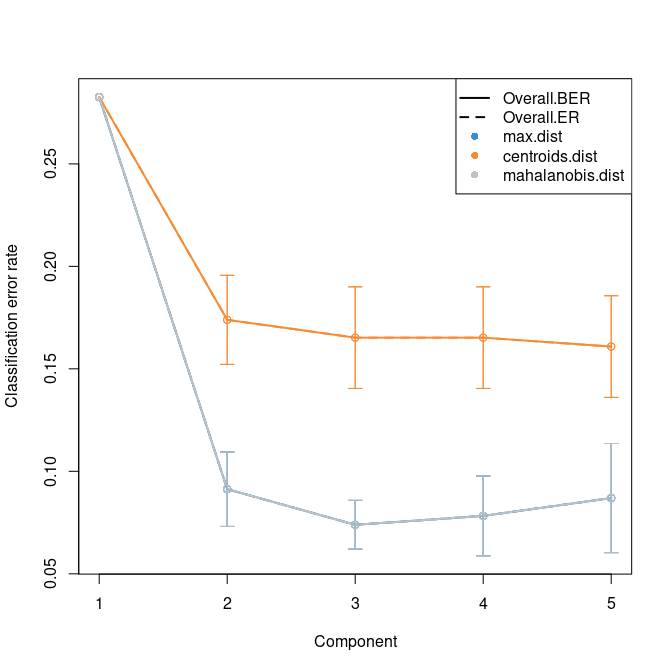

```r
> datos <- list(metabolome = metabolome.basal, microbiome = phylum)
> diablo.integro.obese <- block.splsda(datos, Y = OBESE, ncomp = 5, design = design)
>
> set.seed(123)  # For reproducibility, remove for your analyses
> perf.diablo.integro.obese = perf(diablo.integro.obese, validation = "Mfold", folds = 10,
+     nrepeat = 5)
>
> # perf.diablo.tcga$error.rate # Lists the different types of error rates
>
> # Plot of the error rates based on weighted vote
> plot(perf.diablo.integro.obese)
```

```r
> (ncomp.obese <- perf.diablo.integro.obese$choice.ncomp$WeightedVote["Overall.BER",
+     "centroids.dist"])
```

```
[1] 2
```

```r
> sgccda.res_met_gen.obese = block.splsda(X = datos, Y = OBESE, ncomp = ncomp.obese,
+     design = design)
```

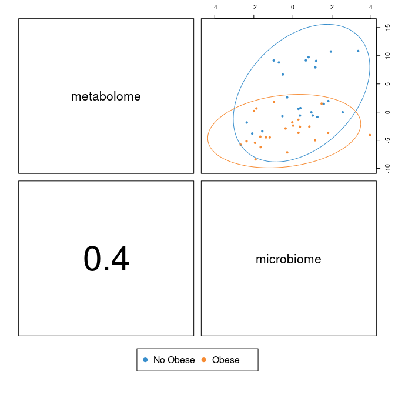

```r
> plotDiablo(sgccda.res_met_gen.obese, ncomp = 1)
```

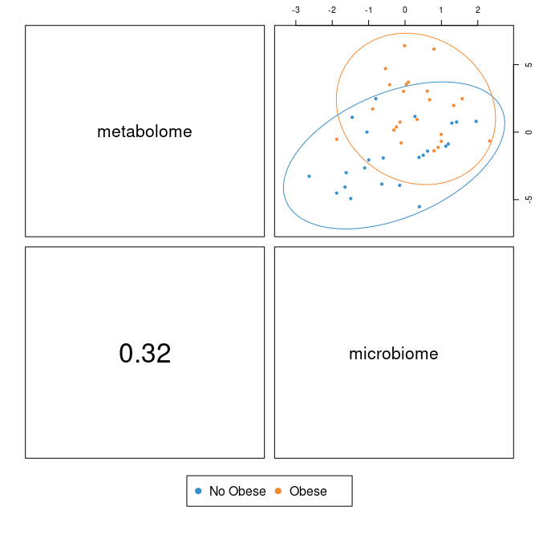

```r
> plotDiablo(sgccda.res_met_gen.obese, ncomp = 2)
```

```r
> # plotDiablo(sgccda.res_met_gen.obese, ncomp = 3)
```

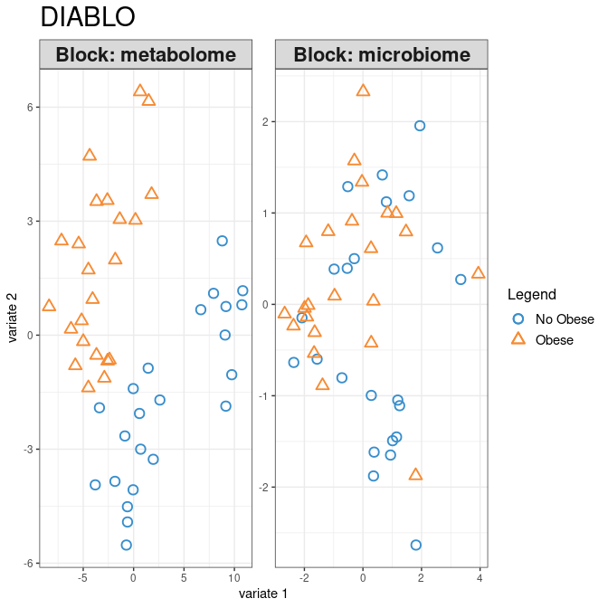

```r
> plotIndiv(sgccda.res_met_gen.obese, ind.names = FALSE, legend = TRUE, title = "DIABLO")
```

SCORE PLOT

```r
> Group <- variables_in_bacteria$GROUP
> Group2 <- variables_in_bacteria$OBESE
> X <- sgccda.res_met_gen.obese$variates$metabolome
> colnames(X) <- paste0("met", colnames(X))
> Y <- sgccda.res_met_gen.obese$variates$microbiome
> colnames(Y) <- paste0("micro", colnames(Y))
> datos <- data.frame(cbind(X, Y))
> str(datos)
```

```
'data.frame':   46 obs. of  4 variables:
 $ metcomp1  : num  7.933 0.584 6.666 8.794 9.163 ...
 $ metcomp2  : num  1.101 -2.06 0.671 2.481 0.754 ...
 $ microcomp1: num  1.148 0.285 -0.517 -0.718 0.662 ...
 $ microcomp2: num  -1.451 -0.996 1.289 -0.804 1.416 ...
```

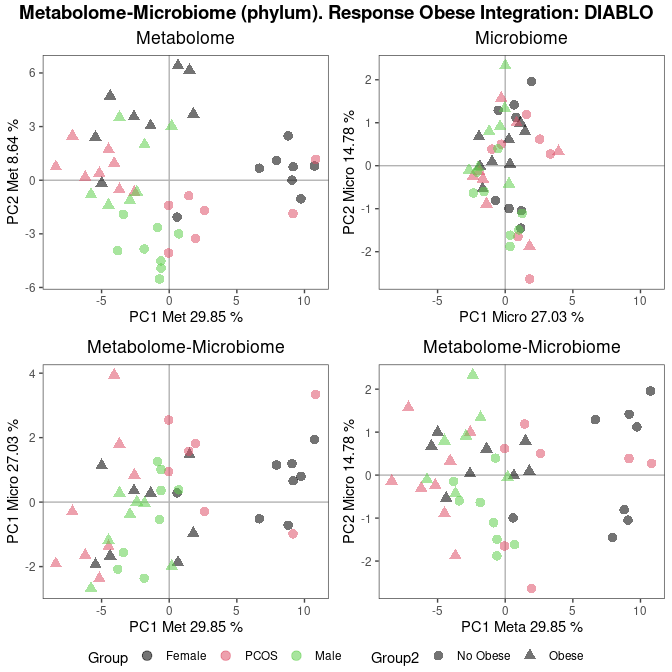

```r
> p1 <- ggplot(datos, aes(metcomp1, metcomp2)) + theme_article() + geom_hline(yintercept = 0,
+     color = "gray70") + geom_vline(xintercept = 0, color = "gray70") + geom_point(aes(color = Group,
+     shape = Group2), alpha = 0.55, size = 3) + coord_cartesian(xlim = c(min(datos[,
+     1]), max(datos[, 1]))) + scale_fill_discrete(name = "Group")
>
>
> grafico1 <- p1 + labs(x = c(paste("PC1 Met", round(100 * sgccda.res_met_gen.obese$prop_expl_var$metabolome[1],
+     2), "%")), y = c(paste("PC2 Met", round(100 * sgccda.res_met_gen.obese$prop_expl_var$metabolome[2],
+     2), "%"))) + ggtitle(paste("Metabolome", sep = " ")) + theme(plot.title = element_text(hjust = 0.5),
+     legend.position = "none") + scale_color_manual(values = 1:3)
>
> p2 <- ggplot(datos, aes(microcomp1, microcomp2)) + theme_article() + geom_hline(yintercept = 0,
+     color = "gray70") + geom_vline(xintercept = 0, color = "gray70") + geom_point(aes(color = Group,
+     shape = Group2), alpha = 0.55, size = 3) + coord_cartesian(xlim = c(min(datos[,
+     1]), max(datos[, 1]))) + scale_fill_discrete(name = "Group")
>
>
> grafico2 <- p2 + labs(x = c(paste("PC1 Micro", round(100 * sgccda.res_met_gen.obese$prop_expl_var$microbiome[1],
+     2), "%")), y = c(paste("PC2 Micro", round(100 * sgccda.res_met_gen.obese$prop_expl_var$microbiome[2],
+     2), "%"))) + ggtitle(paste("Microbiome", sep = " ")) + theme(plot.title = element_text(hjust = 0.5),
+     legend.position = "none") + scale_color_manual(values = 1:3)
>
> p3 <- ggplot(datos, aes(metcomp1, microcomp1)) + theme_article() + geom_hline(yintercept = 0,
+     color = "gray70") + geom_vline(xintercept = 0, color = "gray70") + geom_point(aes(color = Group,
+     shape = Group2), alpha = 0.55, size = 3) + coord_cartesian(xlim = c(min(datos[,
+     1]), max(datos[, 1]))) + scale_fill_discrete(name = "Group")
>
>
> grafico3 <- p3 + labs(x = c(paste("PC1 Met", round(100 * sgccda.res_met_gen.obese$prop_expl_var$metabolome[1],
+     2), "%")), y = c(paste("PC1 Micro", round(100 * sgccda.res_met_gen.obese$prop_expl_var$microbiome[1],
+     2), "%"))) + ggtitle(paste("Metabolome-Microbiome", sep = " ")) + theme(plot.title = element_text(hjust = 0.5),
+     legend.position = "none") + scale_color_manual(values = 1:3)
>
>
> p4 <- ggplot(datos, aes(metcomp1, microcomp2)) + theme_article() + geom_hline(yintercept = 0,
+     color = "gray70") + geom_vline(xintercept = 0, color = "gray70") + geom_point(aes(color = Group,
+     shape = Group2), alpha = 0.55, size = 3) + coord_cartesian(xlim = c(min(datos[,
+     1]), max(datos[, 1]))) + scale_fill_discrete(name = "Group")
>
>
> grafico4 <- p4 + labs(x = c(paste("PC1 Meta", round(100 * sgccda.res_met_gen.obese$prop_expl_var$metabolome[1],
+     2), "%")), y = c(paste("PC2 Micro", round(100 * sgccda.res_met_gen.obese$prop_expl_var$microbiome[2],
+     2), "%"))) + ggtitle(paste("Metabolome-Microbiome", sep = " ")) + theme(plot.title = element_text(hjust = 0.5),
+     legend.position = "none") + scale_color_manual(values = 1:3)
>
> p <- ggarrange(grafico1, grafico2, grafico3, grafico4, common.legend = T, nrow = 2,
+     ncol = 2, legend = "bottom")
> annotate_figure(p, top = text_grob("Metabolome-Microbiome (phylum). Response Obese Integration: DIABLO",
+     color = "black", face = "bold", size = 14))
```

#### interaccion

We are going to keep all variables since we do not have the power.

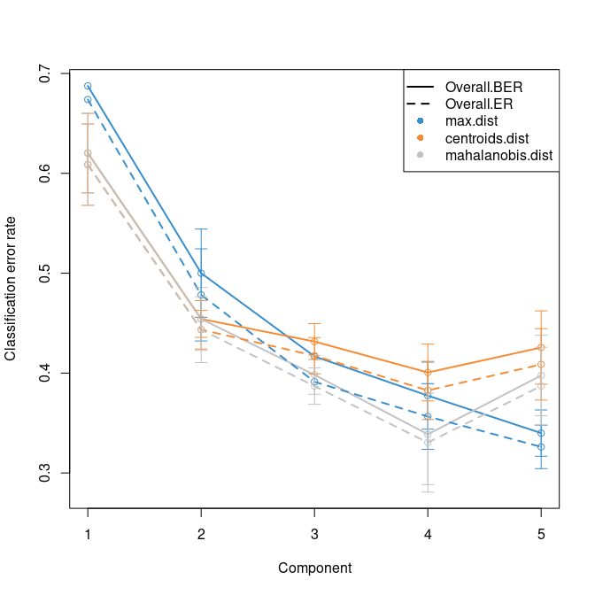

```r
> datos <- list(metabolome = metabolome.basal, microbiome = phylum)
> diablo.integro.interaccion <- block.splsda(datos, Y = interaccion, ncomp = 5, design = design)
>
> set.seed(123)  # For reproducibility, remove for your analyses
> perf.diablo.integro.interaccion = perf(diablo.integro.interaccion, validation = "Mfold",
+     folds = 10, nrepeat = 5)
>
> # perf.diablo.tcga$error.rate # Lists the different types of error rates
>
> # Plot of the error rates based on weighted vote
> plot(perf.diablo.integro.interaccion)
```

```r
> (ncomp.interaccion <- perf.diablo.integro.interaccion$choice.ncomp$WeightedVote["Overall.BER",
+     "centroids.dist"])
```

```
[1] 4
```

```r
> sgccda.res_met_gen.interaccion = block.splsda(X = datos, Y = interaccion, ncomp = ncomp.interaccion,
+     design = design)
```

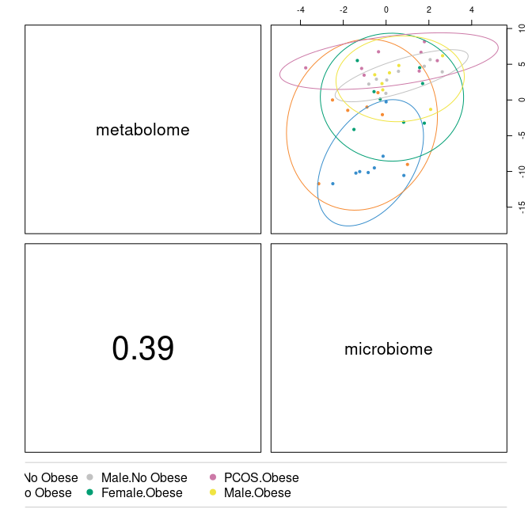

```r
> plotDiablo(sgccda.res_met_gen.interaccion, ncomp = 1)
```

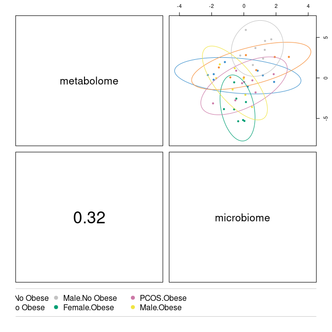

```r
> plotDiablo(sgccda.res_met_gen.interaccion, ncomp = 2)
```

```r
> # plotDiablo(sgccda.res_met_gen.interaccion, ncomp = 3)
```

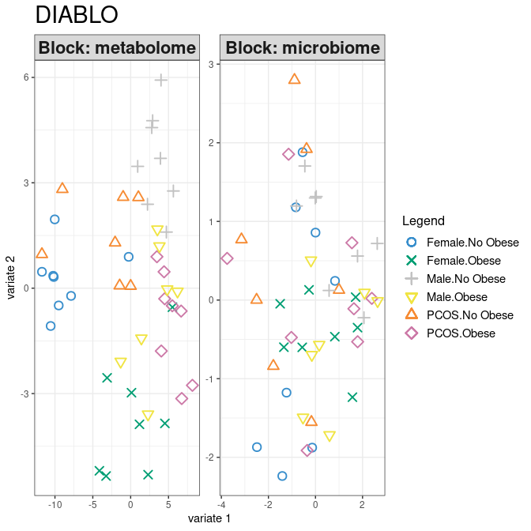

```r
> plotIndiv(sgccda.res_met_gen.interaccion, ind.names = FALSE, legend = TRUE, title = "DIABLO")
```

SCORE PLOT

```r
> Group <- variables_in_bacteria$GROUP
> Group2 <- variables_in_bacteria$OBESE
> X <- sgccda.res_met_gen.interaccion$variates$metabolome
> colnames(X) <- paste0("met", colnames(X))
> Y <- sgccda.res_met_gen.interaccion$variates$microbiome
> colnames(Y) <- paste0("micro", colnames(Y))
> datos <- data.frame(cbind(X, Y))
> str(datos)
```

```
'data.frame':   46 obs. of  8 variables:
 $ metcomp1  : num  -9.504 -0.261 -7.871 -10.565 -10.233 ...
 $ metcomp2  : num  -0.491 0.893 -0.219 -1.076 0.354 ...
 $ metcomp3  : num  -0.629 -1.394 -2.531 -2.194 -0.77 ...
 $ metcomp4  : num  3.75 -1.41 4.38 2.2 1.41 ...
 $ microcomp1: num  -0.54789 0.00153 -0.14019 0.8303 -1.41068 ...
 $ microcomp2: num  1.88 0.858 -1.877 0.244 -2.238 ...
 $ microcomp3: num  -0.3035 -1.201 -1.3749 -0.0831 -0.6808 ...
 $ microcomp4: num  -0.17 0.821 0.862 -0.184 1.37 ...
```

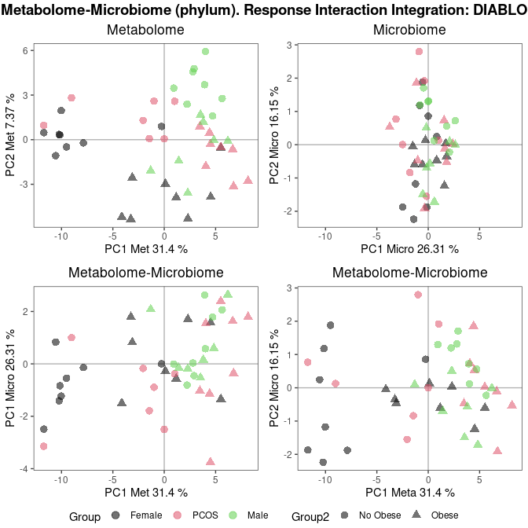

```r
> p1 <- ggplot(datos, aes(metcomp1, metcomp2)) + theme_article() + geom_hline(yintercept = 0,
+     color = "gray70") + geom_vline(xintercept = 0, color = "gray70") + geom_point(aes(color = Group,
+     shape = Group2), alpha = 0.55, size = 3) + coord_cartesian(xlim = c(min(datos[,
+     1]), max(datos[, 1]))) + scale_fill_discrete(name = "Group")
>
>
> grafico1 <- p1 + labs(x = c(paste("PC1 Met", round(100 * sgccda.res_met_gen.interaccion$prop_expl_var$metabolome[1],
+     2), "%")), y = c(paste("PC2 Met", round(100 * sgccda.res_met_gen.interaccion$prop_expl_var$metabolome[2],
+     2), "%"))) + ggtitle(paste("Metabolome", sep = " ")) + theme(plot.title = element_text(hjust = 0.5),
+     legend.position = "none") + scale_color_manual(values = 1:3)
>
> p2 <- ggplot(datos, aes(microcomp1, microcomp2)) + theme_article() + geom_hline(yintercept = 0,
+     color = "gray70") + geom_vline(xintercept = 0, color = "gray70") + geom_point(aes(color = Group,
+     shape = Group2), alpha = 0.55, size = 3) + coord_cartesian(xlim = c(min(datos[,
+     1]), max(datos[, 1]))) + scale_fill_discrete(name = "Group")
>
>
> grafico2 <- p2 + labs(x = c(paste("PC1 Micro", round(100 * sgccda.res_met_gen.interaccion$prop_expl_var$microbiome[1],
+     2), "%")), y = c(paste("PC2 Micro", round(100 * sgccda.res_met_gen.interaccion$prop_expl_var$microbiome[2],
+     2), "%"))) + ggtitle(paste("Microbiome", sep = " ")) + theme(plot.title = element_text(hjust = 0.5),
+     legend.position = "none") + scale_color_manual(values = 1:3)
>
> p3 <- ggplot(datos, aes(metcomp1, microcomp1)) + theme_article() + geom_hline(yintercept = 0,
+     color = "gray70") + geom_vline(xintercept = 0, color = "gray70") + geom_point(aes(color = Group,
+     shape = Group2), alpha = 0.55, size = 3) + coord_cartesian(xlim = c(min(datos[,
+     1]), max(datos[, 1]))) + scale_fill_discrete(name = "Group")
>
>
> grafico3 <- p3 + labs(x = c(paste("PC1 Met", round(100 * sgccda.res_met_gen.interaccion$prop_expl_var$metabolome[1],
+     2), "%")), y = c(paste("PC1 Micro", round(100 * sgccda.res_met_gen.interaccion$prop_expl_var$microbiome[1],
+     2), "%"))) + ggtitle(paste("Metabolome-Microbiome", sep = " ")) + theme(plot.title = element_text(hjust = 0.5),
+     legend.position = "none") + scale_color_manual(values = 1:3)
>
>
> p4 <- ggplot(datos, aes(metcomp1, microcomp2)) + theme_article() + geom_hline(yintercept = 0,
+     color = "gray70") + geom_vline(xintercept = 0, color = "gray70") + geom_point(aes(color = Group,
+     shape = Group2), alpha = 0.55, size = 3) + coord_cartesian(xlim = c(min(datos[,
+     1]), max(datos[, 1]))) + scale_fill_discrete(name = "Group")
>
>
> grafico4 <- p4 + labs(x = c(paste("PC1 Meta", round(100 * sgccda.res_met_gen.interaccion$prop_expl_var$metabolome[1],
+     2), "%")), y = c(paste("PC2 Micro", round(100 * sgccda.res_met_gen.interaccion$prop_expl_var$microbiome[2],
+     2), "%"))) + ggtitle(paste("Metabolome-Microbiome", sep = " ")) + theme(plot.title = element_text(hjust = 0.5),
+     legend.position = "none") + scale_color_manual(values = 1:3)
>
> p <- ggarrange(grafico1, grafico2, grafico3, grafico4, common.legend = T, nrow = 2,
+     ncol = 2, legend = "bottom")
> annotate_figure(p, top = text_grob("Metabolome-Microbiome (phylum). Response Interaction Integration: DIABLO",
+     color = "black", face = "bold", size = 14))
```